# Quantifying the time-varying association between objectively measured physical activity and mortality in US older adults: The NHANES study

## Introduction

The National Health and Nutrition Examination Survey (NHANES) is a program of studies designed to assess the health and nutritional status of adults and children in the United States$^1$. The NHANES accelerometry data is a cross-sectional study of the US population performed in 2-year waves, namely 2003-04 wave and 2005-06 wave. The device placed on the right hip, records uniaxial “intensity” of movement upto 7 days for each participant except during swimming, sleeping, etc. Acceleration summarized into minute-level “activity counts”. The NDI mortality data provides mortality follow-up data through December 31, 2015. It is already known that physical activity is linked with mortality.

Objective: How far into the future does physical activity (PA) predict mortality?

Load the following packages.

```r
library(rnhanesdata)
library(reshape2)
library(ggplot2)
library(gridExtra)
library(dplyr)
library(tableone)
library(survey)
library(survival)
library(survminer)
library(quantreg)
library(reshape2)
library(mgcv)
library(stringr)
```

## 1. Data

We include individuals with

- at least 3 days of data and at least 10 hours of estimated wear time
- non-missing demographic and lifestyle variables and mortality data
- ages 50-84 Individuals who died due to accidents were censored at their time of death. The following chunk of code explains data creation in details.

```r
## load the data from rnhanesdata package
data("PAXINTEN_C");data("PAXINTEN_D")
data("Flags_C");data("Flags_D")
data("Covariate_C");data("Covariate_D")
data("Mortality_2015_C");data("Mortality_2015_D")

## re-code activity counts which are considered "non-wear" to be 0
## this doesn't impact much data, most estimated non-wear times correspond to 0 counts anyway
PAXINTEN_C[,paste0("MIN",1:1440)] <- PAXINTEN_C[,paste0("MIN",1:1440)]*
  Flags_C[,paste0("MIN",1:1440)]
PAXINTEN_D[,paste0("MIN",1:1440)] <- PAXINTEN_D[,paste0("MIN",1:1440)]*
  Flags_D[,paste0("MIN",1:1440)]

## Merge covariate, mortality, and accelerometry data
## note that both PAXINTEN_* and Covariate_* have a column
## called "SDDSRVYR" indicating which NHANES wave the data is associated with.
## To avoid duplicating this column in the merged data, we add this variable to the "by"
## argument in left_join()
AllAct_C <- left_join(PAXINTEN_C, Mortality_2015_C, by = "SEQN") %>%
        left_join(Covariate_C, by=c("SEQN", "SDDSRVYR"))
AllAct_D <- left_join(PAXINTEN_D, Mortality_2015_D, by = "SEQN") %>%
        left_join(Covariate_D, by=c("SEQN", "SDDSRVYR"))

AllFlags_C <- left_join(Flags_C, Mortality_2015_C, by = "SEQN") %>%
        left_join(Covariate_C, by=c("SEQN", "SDDSRVYR"))
AllFlags_D <- left_join(Flags_D, Mortality_2015_D, by = "SEQN") %>%
        left_join(Covariate_D, by=c("SEQN", "SDDSRVYR"))

## clean up the workspace for memory purposes
rm(list=c(paste0(c("PAXINTEN_", "Covariate_","Mortality_2015_","Flags_"),rep(LETTERS[3:4],each=4))))

## combine data for the two waves
AllAct   <- rbind.data.frame(AllAct_C,AllAct_D)
AllFlags <- rbind.data.frame(AllFlags_C,AllFlags_D)


## clean up the workspace again
rm(list=c("AllAct_C","AllAct_D","AllFlags_C","AllFlags_D"))
##############################################################################
##                                                                          ##
##  Section 1b: create new variables/relevel factor variables for analyses  ##
##                                                                          ##
##############################################################################

## Code year 5 mortality, NAs for individuals with follow up less than 5 years and alive
AllAct$yr5_mort <- AllFlags$yr5_mort <- as.integer(ifelse(AllAct$permth_exm/12 <= 5 & AllAct$mortstat == 1, 1,
                                                      ifelse(AllAct$permth_exm/12 < 5 & AllAct$mortstat == 0, NA, 0)))
## Create Age in years using the age at examination (i.e. when participants wore the device)
AllAct$Age <- AllFlags$Age <- AllAct$RIDAGEEX/12

## Re-level comorbidities to assign refused/don't know as not having the condition
## Note that in practice this does not affect many individuals, but it is an
## assumption we're making.
levels(AllAct$CHD) <- levels(AllFlags$CHD) <- list("No" = c("No","Refused","Don't know"),"Yes" = c("Yes"))
levels(AllAct$CHF) <- levels(AllFlags$CHF) <- list("No" = c("No","Refused","Don't know"),"Yes" = c("Yes"))
levels(AllAct$Stroke) <- levels(AllFlags$Stroke) <- list("No" = c("No","Refused","Don't know"),"Yes" = c("Yes"))
levels(AllAct$Cancer) <- levels(AllFlags$Cancer) <- list("No" = c("No","Refused","Don't know"),"Yes" = c("Yes"))
levels(AllAct$Diabetes) <- levels(AllFlags$Diabetes) <- list("No" = c("No","Borderline","Refused","Don't know"),"Yes" = c("Yes"))

## Re-level education to have 3 levels and categorize don't know/refused to be missing
levels(AllAct$EducationAdult) <- levels(AllFlags$EducationAdult) <- list("Less than high school"= c("Less than 9th grade","9-11th grade"),"High school" = c("High school grad/GED or equivalent"),"More than high school" = c("Some College or AA degree", "College graduate or above"))

## Re-level alcohol consumption to include a level for "missing"
levels(AllAct$DrinkStatus) <- levels(AllFlags$DrinkStatus) <- c(levels(AllAct$DrinkStatus),"Missing alcohol")
AllAct$DrinkStatus[is.na(AllAct$DrinkStatus)] <- AllFlags$DrinkStatus[is.na(AllAct$DrinkStatus)] <- "Missing alcohol"

## Re-order columns so that activity and wear/non-wear flags are the last 1440 columns of our two
## data matrices. This is a personal preference and is absolutely not necessary.
act_cols <- which(colnames(AllAct) %in% paste0("MIN",1:1440))
oth_cols <- which(!colnames(AllAct) %in% paste0("MIN",1:1440))
AllAct   <- AllAct[,c(oth_cols,act_cols)]
AllFlags <- AllFlags[,c(oth_cols,act_cols)]
rm(list=c("act_cols","oth_cols"))

###########################################################
##                                                       ##
##  Section 2: Calcualte common accelerometery features  ##
##                                                       ##
###########################################################

## Assign just the activity and wear/non-wear flag data to matrices.
## This makes computing the features faster but is technically required.
act_mat  <- as.matrix(AllAct[,paste0("MIN",1:1440)])
flag_mat <- as.matrix(AllFlags[,paste0("MIN",1:1440)])

## replace NAs with 0s
## As described in the manuscript, this only affects 501 minutes for 1 day, for one subject
act_mat[is.na(act_mat)]   <- 0
flag_mat[is.na(flag_mat)] <- 0

AllAct$TAC   <- AllFlags$TAC   <- rowSums(act_mat)
AllAct$TLAC  <- AllFlags$TLAC  <- rowSums(log(1+act_mat))
AllAct$WT    <- AllFlags$WT    <- rowSums(flag_mat)
AllAct$ST    <- AllFlags$ST    <- rowSums(act_mat < 100)
AllAct$MVPA  <- AllFlags$MVPA  <- rowSums(act_mat >= 2020)

## calculate fragmentation measures
bout_mat <- apply(act_mat >= 100, 1, function(x){
    mat <- rle(x)
    sed <- mat$lengths[which(mat$values == FALSE)]
    act <- mat$length[mat$values == TRUE]

    sed <- ifelse(length(sed) == 0, NA, mean(sed))
    act <- ifelse(length(act) == 0, NA, mean(act))
    c(sed,act)
})

AllAct$SBout <- AllFlags$SBout <- bout_mat[1,]
AllAct$ABout <- AllFlags$ABout <- bout_mat[2,]
AllAct$SATP  <- AllFlags$SATP  <- 1/AllAct$SBout
AllAct$ASTP  <- AllFlags$ASTP  <- 1/AllAct$ABout
rm(list=c("act_mat","flag_mat","bout_mat"))

###########################################
##                                       ##
##  Section 3: Apply exclusion criteria  ##
##                                       ##
###########################################

## make dataframe with one row per individual to create table 1.
## Remove columns associated with activity to avoid any confusion.
table_dat <- AllAct[!duplicated(AllAct$SEQN),-which(colnames(AllAct) %in% c(paste0("MIN",1:1440),
                                                                            "TAC","TLAC","WT","ST","MVPA","SBout","ABout","SATP","ASTP"))]

## subset based on our age inclusion/exclusion criteria
## note that individuals age 85 and over are coded as NA
table_dat <- subset(table_dat, !(Age < 50 | is.na(Age)))

## get the SEQN (id variable) associated with individuals with fewer than 3 days accelerometer
## wear time with at least 10 hours OR had their data quality/device calibration flagged by NHANES
keep_inx       <- exclude_accel(AllAct, AllFlags)
Act_Analysis   <- AllAct[keep_inx,]
Flags_Analysis <- AllFlags[keep_inx,]
nms_rm         <- unique(c(Act_Analysis$SEQN[-which(Act_Analysis$SEQN %in% names(table(Act_Analysis$SEQN))[table(Act_Analysis$SEQN)>=3])],setdiff(AllAct$SEQN,Act_Analysis$SEQN)))
rm(list=c("keep_inx"))

## Additional inclusion/exclusion criteria.
## Aside from mortality or accelerometer weartime, the only missingness is in
## Education (6) and BMI (35).
criteria_vec <- c("(is.na(table_dat$BMI_cat))",         # missing BMI
                  "(is.na(table_dat$EducationAdult))",  # missing education
                  "(table_dat$SEQN %in% nms_rm)",       # too few "good" days of accel data
                  "((!table_dat$eligstat %in% 1) | is.na(table_dat$mortstat) |
                  is.na(table_dat$permth_exm))") # missing mortality data, or accidental death

## create matrix of pairwise missing data based on our exclusion criterial
tab_miss <- matrix(NA, ncol=length(criteria_vec), nrow=length(criteria_vec))
for(i in seq_along(criteria_vec)){
    for(j in seq_along(criteria_vec)){
        eval(parse(text=paste0("miss_cur <- which(", criteria_vec[i], "&", criteria_vec[j],")")))
        tab_miss[i,j] <- length(miss_cur)
        rm(list=c("miss_cur"))
    }
}
rownames(tab_miss) <- colnames(tab_miss) <- c("BMI","Education","Bad Accel Data","Mortality")
rm(list=c("i","j"))
## view missing data pattern
tab_miss
```

```
##                BMI Education Bad Accel Data Mortality
## BMI             35         0              8         0
## Education        0         6              2         0
## Bad Accel Data   8         2            517         0
## Mortality        0         0              0         6
```

```r
## add in column indicating exclusion:
##   Exclude = 1 indicates an individual does not meet our inclusion criteria
##   Exclude = 0 indicates an individual does meet our inclusion criteria
eval(parse(text=paste0("table_dat$Exclude <- as.integer(", paste0(criteria_vec,collapse="|"), ")")))

## Create our dataset for analysis with one row per subject
## containing only those subjects who meet our inclusion criteria.
data_analysis  <- subset(table_dat, Exclude == 0)
data_analysis$mortstat <- ifelse((data_analysis$ucod_leading %in% "004" & data_analysis$mortstat ==1),0,data_analysis$mortstat)
## get adjusted survey weights using the reweight_accel function
data_analysis  <- reweight_accel(data_analysis)

## Get activity/flag data for only those included participants AND who have 3 good days of data.
## Since we've already removed the "bad" days from Act_Analysis and Act_Flags,
## we need only subset based on subject ID now.
Act_Analysis   <- subset(Act_Analysis, SEQN %in% data_analysis$SEQN)
Flags_Analysis <- subset(Flags_Analysis, SEQN %in% data_analysis$SEQN)

## calculate subject specific averages of the accelerometry features
## using only the "good" days of data
act_var_nms <- c("TAC","TLAC","WT","ST","MVPA","SATP","ASTP")
for(i in act_var_nms){
    data_analysis[[i]] <- vapply(data_analysis$SEQN, function(x) mean(Act_Analysis[[i]][Act_Analysis$SEQN==x],na.rm=TRUE), numeric(1))
}

## verify there's no missingness in the rest of our predictors of interest
vars_interest <- c("Age", "Gender", "Race", "EducationAdult", "SmokeCigs", "DrinkStatus", "BMI_cat",
                   "Diabetes","CHF",  "CHD", "Stroke",
                   "Cancer", "MobilityProblem",
                   "permth_exm")

## clean up the workspace
rm(list=c("AllAct","AllFlags","i","criteria_vec","nms_rm","tab_miss"))
gc()
```

```
##            used  (Mb) gc trigger   (Mb) limit (Mb)  max used   (Mb)
## Ncells  2125194 113.5    4088558  218.4         NA   4088558  218.4
## Vcells 33778456 257.8  763437957 5824.6      16384 954295973 7280.8
```

```r
###### data for EDA
data_analysis$time <- data_analysis$permth_exm/12
data_eda = data_analysis

# number of participants
nrow(data_analysis)
```

```
## [1] 3218
```

```r
# number of deaths
sum(data_analysis$mortstat==1)
```

```
## [1] 867
```

```r
# person years of follow up time.
sum(data_analysis$time)
```

```
## [1] 30926.67
```

## 2. Exploratory Data Analysis

We denote the quantile transformed total activity counts, TAC as TACq. Here we plot the distribution of TACq for survivors (individuals at risk) at the end of a year vs those who died in the preceding 1 year interval for mortality data 2015.

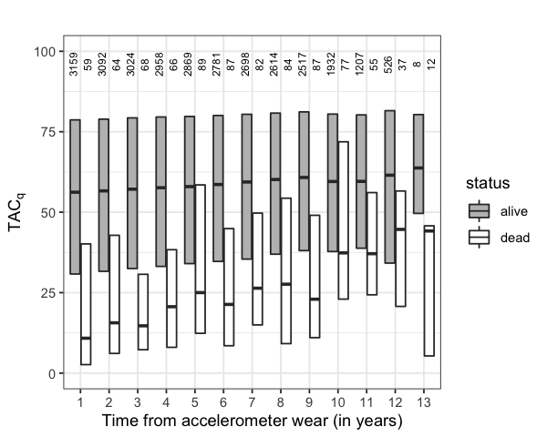

Figure 1. Distributions of TACq for individuals who survived at the end of each year (shown in gray) versus those who died in the preceding 1 year interval (shown in white).

```r
### creating 13 columns for 13 years of follow-up marking indivuals
### who are alive at the end of each year as "alive" and "dead" for
### individuals who experience death in between previous year to this year
data_eda$TAC <- 100*ecdf(data_eda$TAC)(data_eda$TAC)
data_eda$yr_1 <- ifelse(data_eda$time <= 1 &
                               data_eda$mortstat == 1, "dead", "alive")
for(i in 2:14)
{
  varname = paste0("yr_",i)
  data_eda = data_eda %>% mutate(!!varname := NA)
  ind = which(colnames(data_eda) == varname)
  data_eda[,ind] <- ifelse(data_eda$time <= (i-1) |
                                  (data_eda$time < i & data_eda$mortstat == 0), NA,
                                ifelse(data_eda$time > (i-1) &
                                         data_eda$time <= i &
                                         data_eda$mortstat == 1,"dead","alive"))
}

yr_name <- paste0("yr_",seq(1,13,1))

### Preparing the data for boxplot
colnames(data_eda)[52] = "weight"
inx_adj = which(grepl("adj",colnames(data_eda)))
data_eda = data_eda[,-inx_adj] ## removing unnecessary columns
inx_sp <- which(grepl("yr_",colnames(data_eda)))
inx_sp1 <- colnames(data_eda)[-inx_sp]

data_eda_1 <- melt(data_eda, id.vars=inx_sp1)
data_eda_1 <- subset(data_eda_1, !value %in% NA)
data_eda_1$status <- data_eda_1$value
ind <- which(grepl("TAC",colnames(data_eda_1)))
```

From the boxplot, we can visualise that the median TACq for the alive population is more than that of the dead population. In addition, an increasing trend in the median TACq is observed for the dead population. We present the summary staistics for the risk factors among these two populations in the following table.

Table 1. Distribution summaries for the traditional risk factors and accelerometry derived variables by mortality status (alive/deceased).

|  | Alive | Deceased |
| --- | --- | --- |
| n | 2351 | 867 |
| Age (mean (SD)) | 63.53 (8.77) | 72.53 (8.94) |
| Gender = Female (%) | 1251 (53.2) | 345 (39.8) |
| Race (%) |  |  |
| White | 1320 (56.1) | 552 (63.7) |
| Mexican American | 446 (19.0) | 132 (15.2) |
| Other Hispanic | 48 ( 2.0) | 13 ( 1.5) |
| Black | 455 (19.4) | 150 (17.3) |
| Other | 82 ( 3.5) | 20 ( 2.3) |
| EducationAdult (%) |  |  |
| Less than high school | 663 (28.2) | 367 (42.3) |
| High school | 584 (24.8) | 215 (24.8) |
| More than high school | 1104 (47.0) | 285 (32.9) |
| SmokeCigs (%) |  |  |
| Never | 1142 (48.6) | 295 (34.0) |
| Former | 836 (35.6) | 401 (46.3) |
| Current | 373 (15.9) | 171 (19.7) |
| DrinkStatus (%) |  |  |
| Moderate Drinker | 1204 (51.2) | 317 (36.6) |
| Non-Drinker | 929 (39.5) | 440 (50.7) |
| Heavy Drinker | 124 ( 5.3) | 65 ( 7.5) |
| Missing alcohol | 94 ( 4.0) | 45 ( 5.2) |
| DrinksPerWeek (mean (SD)) | 2.44 (5.73) | 3.03 (8.46) |
| BMI_cat (%) |  |  |
| Normal | 588 (25.0) | 243 (28.0) |
| Underweight | 14 ( 0.6) | 16 ( 1.8) |
| Overweight | 903 (38.4) | 323 (37.3) |
| Obese | 846 (36.0) | 285 (32.9) |
| Diabetes = Yes (%) | 353 (15.0) | 222 (25.6) |
| CHF = Yes (%) | 77 ( 3.3) | 114 (13.1) |
| CHD = Yes (%) | 136 ( 5.8) | 131 (15.1) |
| Stroke = Yes (%) | 86 ( 3.7) | 107 (12.3) |
| Cancer = Yes (%) | 293 (12.5) | 212 (24.5) |
| MobilityProblem = Any Difficulty (%) | 587 (25.0) | 453 (52.2) |
| TAC (mean (SD)) | 56.55 (26.79) | 32.29 (26.81) |

## 3. Modeling

1. In the modeling part, we first fit a Cox proportional hazard model where all the risk factors including the physical activity count, TACq is considered fixed.

```r
####---------------- fixed model with weights ---------------####
data_analysis$TAC <- 100*ecdf(data_analysis$TAC)(data_analysis$TAC)

test <- data_analysis[,c(1,7,13:14,21:31,33,35,52:53,60)]

demo_vars <- c("Age", "Gender", "Race", "EducationAdult", "SmokeCigs", "DrinkStatus", "BMI_cat",
               "Diabetes","CHF",  "CHD", "Stroke", "Cancer", "MobilityProblem")

cut.points <- unique(test$time[test$mortstat == 1])
test2 <- survSplit(data = test, cut = cut.points, end = "time",
                   start = "time0", event = "mortstat")

form1 <- paste0(paste0(demo_vars, collapse="+"),"+TAC")
data_analysis_svy <- svydesign(id= ~SDMVPSU, strata = ~SDMVSTRA,
                               weights = ~wtmec4yr_adj_norm, data = test2, nest = TRUE)

fit1 <- svycoxph(as.formula(paste("Surv(time0,time,mortstat) ~", form1)),
                 design = data_analysis_svy)
```

Table 2. Estimated hazard ratio (HR), 95% confidence interval and P-values in the fully adjusted Cox Proportional Hazard model with fixed TACq

|  | Estimate | Lower CI | Upper CI | Pr(>\|t\|) |
| --- | --- | --- | --- | --- |
| Age | 1.069 | 1.057 | 1.082 | 0.000 |
| GenderFemale | 0.561 | 0.462 | 0.680 | 0.000 |
| RaceMexican American | 0.999 | 0.785 | 1.270 | 0.991 |
| RaceOther Hispanic | 1.288 | 0.748 | 2.217 | 0.361 |
| RaceBlack | 1.029 | 0.826 | 1.281 | 0.799 |
| RaceOther | 0.901 | 0.476 | 1.705 | 0.748 |
| EducationAdultHigh school | 0.916 | 0.688 | 1.220 | 0.549 |
| EducationAdultMore than high school | 0.792 | 0.616 | 1.017 | 0.067 |
| SmokeCigsFormer | 1.324 | 1.053 | 1.665 | 0.016 |
| SmokeCigsCurrent | 2.052 | 1.705 | 2.470 | 0.000 |
| DrinkStatusNon-Drinker | 1.404 | 1.154 | 1.707 | 0.001 |
| DrinkStatusHeavy Drinker | 1.709 | 1.107 | 2.637 | 0.015 |
| DrinkStatusMissing alcohol | 2.025 | 1.406 | 2.917 | 0.000 |
| BMI_catUnderweight | 2.598 | 1.345 | 5.018 | 0.004 |
| BMI_catOverweight | 0.760 | 0.658 | 0.878 | 0.000 |
| BMI_catObese | 0.833 | 0.662 | 1.049 | 0.120 |
| DiabetesYes | 1.302 | 1.100 | 1.541 | 0.002 |
| CHFYes | 1.779 | 1.378 | 2.296 | 0.000 |
| CHDYes | 1.132 | 0.891 | 1.439 | 0.309 |
| StrokeYes | 1.284 | 0.992 | 1.662 | 0.058 |
| CancerYes | 1.357 | 1.124 | 1.637 | 0.001 |
| MobilityProblemAny Difficulty | 1.489 | 1.314 | 1.688 | 0.000 |
| TAC<sub>q</sub> | 0.983 | 0.979 | 0.987 | 0.000 |

2. We test for the proportionality assumption of all the risk factors for the Cox regression model fit. The model shows that a 2% decrease in the risk of death for one percentile increase in TAC. However, the global test of proportionality is rejected with p-value 0.002 and the individual test for TACq is rejected with p-value 0.008.
3. We used a time-varying Cox model where the parameter for TACq, $\beta_{TACq}(t)$ is fit non-parametrically using penalized cubic spline. This is implemented using *mgcv* package in R. We were not able to account for the survey weights for this model.

```r
#### fitting \beta(t) non-parametrically
ut <- sort(unique(data_analysis$time[data_analysis$mortstat==1]))
nt <- length(ut)
di_tv <- ti_tv <- inx_tv <- c()
for(i in 1:nt){
  inx_tv_i <- which(data_analysis$time >= ut[i])
  di_tv_i  <- as.numeric(data_analysis$mortstat[inx_tv_i] *
                           (data_analysis$time[inx_tv_i] == ut[i] ) )
  ti_tv  <- c(ti_tv, rep(ut[i], length(inx_tv_i)))
  di_tv  <- c(di_tv, di_tv_i)
  inx_tv <- c(inx_tv, inx_tv_i)
}

data_tv <- data.frame(data_analysis[inx_tv,], di_tv = di_tv, ti_tv = ti_tv, t_fac = factor(ti_tv))


fit_tv_gam_tac <- bam(di_tv ~  t_fac - 1 + Age + Gender + Race + EducationAdult + SmokeCigs +
                        DrinkStatus + BMI_cat + Diabetes + CHF + CHD + Stroke + Cancer +
                        MobilityProblem + s(ti_tv, by=TAC),data=data_tv,
                      family=quasipoisson, method="fREML",discrete=TRUE)

tind <-  seq(0,13, len=100)
df_pred <- data_tv
df_pred$ti_tv = df_pred$TAC <- NULL
coef_fit <- predict(fit_tv_gam_tac,
                    newdata=data.frame(df_pred[1,], ti_tv =tind, TAC=1),
                    se.fit=TRUE,type='terms')
```

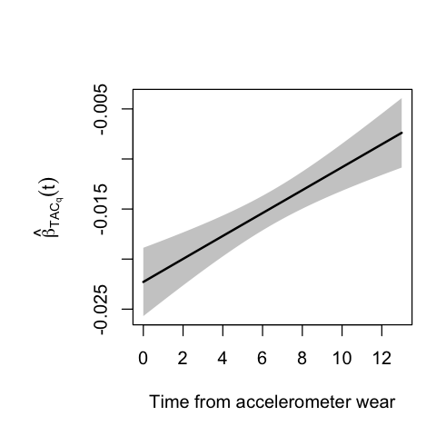

Figure 2. Adjusted estimated eta(t) (black solid) with 95% pointwise confidence bands (shaded areas) non-parametric fit for the effect of one percentile increase of TAC on mortality risk as a function of time.

Table 3. Estimated hazard ratio (HR), 95% confidence interval and P-values in the fully adjusted Cox model with time varying coefficient for TACq.

|  | Estimate | Lower CI | Upper CI | Pr(>\|t\|) |
| --- | --- | --- | --- | --- |
| Age | 1.069 | 1.057 | 1.082 | 0.000 |
| GenderFemale | 0.565 | 0.467 | 0.684 | 0.000 |
| RaceMexican American | 1.000 | 0.788 | 1.269 | 0.999 |
| RaceOther Hispanic | 1.284 | 0.745 | 2.215 | 0.368 |
| RaceBlack | 1.028 | 0.827 | 1.278 | 0.803 |
| RaceOther | 0.916 | 0.487 | 1.724 | 0.787 |
| EducationAdultHigh school | 0.916 | 0.690 | 1.216 | 0.544 |
| EducationAdultMore than high school | 0.792 | 0.617 | 1.016 | 0.067 |
| SmokeCigsFormer | 1.322 | 1.054 | 1.658 | 0.016 |
| SmokeCigsCurrent | 2.057 | 1.712 | 2.471 | 0.000 |
| DrinkStatusModerate Drinker | 0.713 | 0.587 | 0.866 | 0.001 |
| DrinkStatusHeavy Drinker | 1.222 | 0.803 | 1.861 | 0.350 |
| DrinkStatusMissing alcohol | 1.426 | 0.981 | 2.073 | 0.063 |
| BMI_catUnderweight | 2.572 | 1.329 | 4.979 | 0.005 |
| BMI_catOverweight | 0.766 | 0.664 | 0.884 | 0.000 |
| BMI_catObese | 0.837 | 0.669 | 1.048 | 0.121 |
| DiabetesYes | 1.308 | 1.109 | 1.543 | 0.001 |
| CHFYes | 1.761 | 1.362 | 2.278 | 0.000 |
| CHDYes | 1.133 | 0.893 | 1.437 | 0.303 |
| StrokeYes | 1.270 | 0.982 | 1.643 | 0.068 |
| CancerYes | 1.355 | 1.124 | 1.634 | 0.001 |
| MobilityProblemAny Difficulty | 1.476 | 1.301 | 1.675 | 0.000 |
| TAC<sub>q</sub> | 0.974 | 0.965 | 0.984 | 0.000 |
| Time*TAC<sub>q</sub> | 1.001 | 1.000 | 1.003 | 0.021 |

The covariate adjusted effect of one percentile increase in TACq corresponds to an HR = 0.974 (CI: (0.965,0.984); p < 0.001) for mortality immediately after the PA measurement and HR = 0.991 (CI: (0.985, 0.997); p = 0.0016475) 12 years later. The HR increases at a rate of 0.139 percent per year (CI: (0.02, 0.257) percent increase in HR per year; p = 0.021).

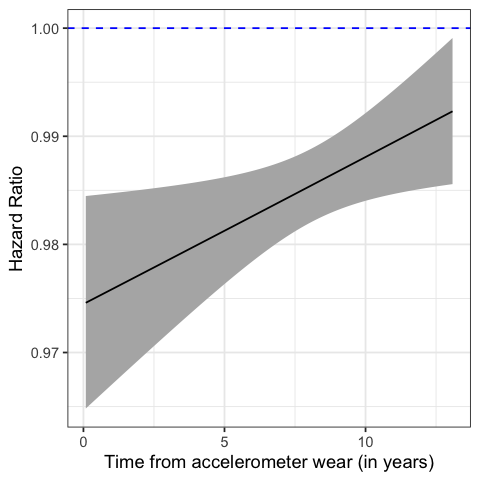

Figure 4. Adjusted estimated Hazard Ratio (black solid) linear fit with 95% pointwise confidence bands (shaded areas) for the effect of one percentile increase of TAC on mortality risk as a function of time.

6. We consider a healthy white male who attended more than high school, with a normal BMI, and no history of diabetes, CHF, CHD, cancer, stroke, mobility problem, alcohol consumption, and cigarette smoking. For two different age, 55 years and 75 years, we plot the survival functions are shown by quartiles of TACq. The quantiles values are adjusted for age using a quantile regression of TACq on age.

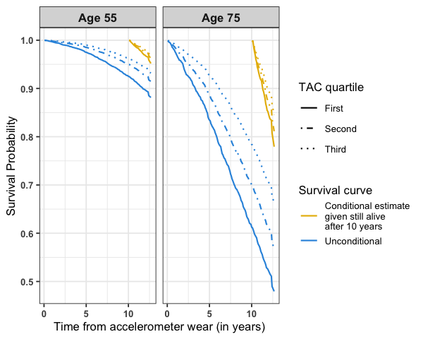

Figure 5. Covariate-adjusted estimated survival functions for a healthy white male age 55 (left panel) and 75 (right panel) at the baseline visit, respectively by quartiles of TACq: first quartile (solid line), second quartile (dashed) and third quartile (dotted).

```r
#####----- survival plot
rqfit1 <- rq(TAC ~ Age, data = test, tau = c(0.25))
rqfit2 <- rq(TAC ~ Age, data = test, tau = c(0.5))
rqfit3 <- rq(TAC ~ Age, data = test, tau = c(0.75))

newdata <- data.frame(Age=rbind(55,75))
pred1 <- predict(rqfit1,newdata=newdata)
pred2 <- predict(rqfit2,newdata=newdata)
pred3 <- predict(rqfit3,newdata=newdata)

##prediction at newdata
last <- test2$SEQN[which.max(test2$time)]
intervals <- test2[test2$SEQN == last, c("time0", "time", "mortstat")]
#intervals[nrow(intervals),] = c(12.66667,13,0)
#intervals[nrow(intervals)+1,] = c(13,13.08333,0)

covs1 <- data.frame(Age=55,Gender="Male",BMI_cat="Normal",
                    Race="White",Diabetes="No",CHF="No",CHD="No",
                    Stroke="No", Cancer="No",MobilityProblem="No Difficulty",
                    EducationAdult="More than high school", SmokeCigs="Never",
                    DrinkStatus="Non-Drinker",TAC=pred1[1])

covs2 <- data.frame(Age=55,Gender="Male",BMI_cat="Normal",
                    Race="White",Diabetes="No",CHF="No",CHD="No",
                    Stroke="No", Cancer="No",MobilityProblem="No Difficulty",
                    EducationAdult="More than high school", SmokeCigs="Never",
                    DrinkStatus="Non-Drinker",TAC=pred2[1])

covs3 <- data.frame(Age=55,Gender="Male",BMI_cat="Normal",
                    Race="White",Diabetes="No",CHF="No",CHD="No",
                    Stroke="No", Cancer="No",MobilityProblem="No Difficulty",
                    EducationAdult="More than high school", SmokeCigs="Never",
                    DrinkStatus="Non-Drinker",TAC=pred3[1])
# vardefn <- function(data) {
#   data$TAC_time <- data$TAC * data$time
#   return(data)
# }
#     Min.   1st Qu.    Median      Mean   3rd Qu.      Max.
#-1.763005 -0.734484 -0.144802  0.000443  0.536557  6.292688
newdata1 <- data.frame(covs1, intervals, row.names = NULL)
newdata2 <- data.frame(covs2, intervals, row.names = NULL)
newdata3 <- data.frame(covs3, intervals, row.names = NULL)
newdata1 <- vardefn(newdata1)
newdata2 <- vardefn(newdata2)
newdata3 <- vardefn(newdata3)

shat1 = summary(survfit(fit2, newdata = newdata1,individual = TRUE))
shat2 = summary(survfit(fit2, newdata = newdata2,individual = TRUE))
shat3 = summary(survfit(fit2, newdata = newdata3,individual = TRUE))

store <- data.frame("time"=shat1$time,"TAC1"=shat1$surv,"TAC2"=shat2$surv,
                    "TAC3"=shat3$surv)

## given survival of 10 years
shat11 = summary(survfit(fit2, newdata = newdata1,individual = TRUE,start.time = 10))
shat21 = summary(survfit(fit2, newdata = newdata2,individual = TRUE,start.time = 10))
shat31 = summary(survfit(fit2, newdata = newdata3,individual = TRUE,start.time = 10))

store1 <- data.frame("time"=shat11$time,"TAC11"=shat11$surv,"TAC21"=shat21$surv,"TAC31"=shat31$surv)

#plotting 0 years survival and at least 10 years survival individuals

inx_sp <- which(grepl("TAC",colnames(store)))
inx_sp1 <- colnames(store)[-inx_sp]
temp <- melt(store, id.vars=inx_sp1)
temp1 <- melt(store1, id.vars=inx_sp1)
temp2 <- rbind(temp,temp1)
```

In the above figure, the blue curves correspond to the survival function estimates at baseline and the yellow curves correspond to survival functions conditional on being alive 10 years after the baseline measurement.

The difference between the conditional survival curves for the three quartiles of TACq, though visible, has decreased relative to the survival curves at baseline for both the age-groups. For example, by five years after baseline the estimated survival probabilities are substantially different (0.975 for the first quartile, 0.985 for the median, and 0.99 for the third quartile) whereas the estimated survival probability at 13 years conditional on survival for 10 years after the baseline measurements are 0.952 for the first quartile, 0.962 for the median, and 0.968 for the third quartile of baseline TACq

```r
data_analysis$age_group <- ifelse(data_analysis$Age < 70,"50-70","70-84")

data_analysis_band1 <- subset(data_analysis, age_group == "50-70")
data_analysis_band2 <- subset(data_analysis, age_group == "70-84")

test_band1 <- data_analysis_band1[,c(1,7,13:14,21:31,33,35,52:53,60)]

cut.points <- unique(test_band1$time[test_band1$mortstat == 1])
test2_band1 <- survSplit(data = test_band1, cut = cut.points, end = "time",start = "time0", event = "mortstat")

vardefn <- function(data) {
  data$time_TAC <- data$TAC * data$time
  return(data)
}
test2_band1 <- vardefn(test2_band1)
test2_band1$DrinkStatus = relevel(test2_band1$DrinkStatus, ref = "Non-Drinker")

form2 <- paste0(paste0(demo_vars, collapse="+"),"+TAC+time_TAC")
data_analysis_svy <- svydesign(id= ~SDMVPSU, strata = ~SDMVSTRA,
                               weights = ~wtmec4yr_adj_norm, data = test2_band1, nest = TRUE)

fit_band1 <- svycoxph(as.formula(paste("Surv(time0,time,mortstat) ~", form2)),
                 design = data_analysis_svy)
summary(fit_band1)
```

```
## Stratified 1 - level Cluster Sampling design (with replacement)
## With (60) clusters.
## svydesign(id = ~SDMVPSU, strata = ~SDMVSTRA, weights = ~wtmec4yr_adj_norm,
##     data = test2_band1, nest = TRUE)
```

```
## Call:
## svycoxph(formula = as.formula(paste("Surv(time0,time,mortstat) ~",
##     form2)), design = data_analysis_svy)
##
##   n= 229434, number of events= 309
##
##                                          coef exp(coef)  se(coef)
## Age                                  0.036066  1.036724  0.012443
## GenderFemale                        -0.518715  0.595285  0.140443
## RaceMexican American                -0.092189  0.911933  0.352051
## RaceOther Hispanic                   0.723211  2.061040  0.357808
## RaceBlack                            0.088579  1.092621  0.201947
## RaceOther                            0.335114  1.398099  0.295894
## EducationAdultHigh school           -0.301245  0.739897  0.183419
## EducationAdultMore than high school -0.571134  0.564884  0.165849
## SmokeCigsFormer                      0.585202  1.795354  0.180050
## SmokeCigsCurrent                     0.950026  2.585777  0.188833
## DrinkStatusModerate Drinker         -0.480994  0.618169  0.153335
## DrinkStatusHeavy Drinker             0.265216  1.303713  0.223260
## DrinkStatusMissing alcohol           0.369176  1.446543  0.254241
## BMI_catUnderweight                   0.431269  1.539210  0.561150
## BMI_catOverweight                   -0.145741  0.864381  0.181848
## BMI_catObese                         0.020718  1.020934  0.178060
## DiabetesYes                          0.362505  1.436925  0.161433
## CHFYes                               0.666937  1.948260  0.208637
## CHDYes                               0.269161  1.308866  0.206716
## StrokeYes                            0.463872  1.590219  0.214119
## CancerYes                            0.553045  1.738538  0.166038
## MobilityProblemAny Difficulty        0.542164  1.719724  0.146683
## TAC                                 -0.027563  0.972814  0.005848
## time_TAC                             0.001721  1.001722  0.000786
##                                     robust se      z Pr(>|z|)
## Age                                  0.010060  3.585 0.000337 ***
## GenderFemale                         0.159576 -3.251 0.001152 **
## RaceMexican American                 0.211395 -0.436 0.662765
## RaceOther Hispanic                   0.366318  1.974 0.048351 *
## RaceBlack                            0.171906  0.515 0.606360
## RaceOther                            0.415989  0.806 0.420484
## EducationAdultHigh school            0.239469 -1.258 0.208403
## EducationAdultMore than high school  0.194023 -2.944 0.003244 **
```

[output cut: 62 more lines]

```
## CHFYes                                 3.1976
## CHDYes                                 2.0840
## StrokeYes                              2.4750
## CancerYes                              2.5551
## MobilityProblemAny Difficulty          2.2278
## TAC                                    0.9921
## time_TAC                               1.0041
##
## Concordance= 0.81  (se = 0.018 )
## Likelihood ratio test= NA  on 24 df,   p=NA
## Wald test            = 5523  on 24 df,   p=<2e-16
## Score (logrank) test = NA  on 24 df,   p=NA
##
##   (Note: the likelihood ratio and score tests assume independence of
##      observations within a cluster, the Wald and robust score tests do not).
```

```r
test_band2 <- data_analysis_band2[,c(1,7,13:14,21:31,33,35,52:53,60)]

cut.points <- unique(test_band2$time[test_band2$mortstat == 1])
test2_band2 <- survSplit(data = test_band2, cut = cut.points, end = "time",start = "time0", event = "mortstat")

test2_band2 <- vardefn(test2_band2)
test2_band2$DrinkStatus = relevel(test2_band2$DrinkStatus, ref = "Non-Drinker")

data_analysis_svy <- svydesign(id= ~SDMVPSU, strata = ~SDMVSTRA,
                               weights = ~wtmec4yr_adj_norm, data = test2_band2, nest = TRUE)

fit_band2 <- svycoxph(as.formula(paste("Surv(time0,time,mortstat) ~", form2)),
                 design = data_analysis_svy)
summary(fit_band2)
```

```
## Stratified 1 - level Cluster Sampling design (with replacement)
## With (60) clusters.
## svydesign(id = ~SDMVPSU, strata = ~SDMVSTRA, weights = ~wtmec4yr_adj_norm,
##     data = test2_band2, nest = TRUE)
```

```
## Call:
## svycoxph(formula = as.formula(paste("Surv(time0,time,mortstat) ~",
##     form2)), design = data_analysis_svy)
##
##   n= 113683, number of events= 558
##
##                                           coef  exp(coef)   se(coef)
## Age                                  0.1077371  1.1137549  0.0117895
## GenderFemale                        -0.6502656  0.5219071  0.0985750
## RaceMexican American                 0.1431977  1.1539579  0.2794895
## RaceOther Hispanic                  -0.1867546  0.8296473  0.4125791
## RaceBlack                           -0.0824638  0.9208448  0.1737546
## RaceOther                           -0.3944340  0.6740614  0.3390630
## EducationAdultHigh school            0.0981768  1.1031578  0.1169564
## EducationAdultMore than high school  0.0145840  1.0146909  0.1168169
## SmokeCigsFormer                      0.1272613  1.1357137  0.1037859
## SmokeCigsCurrent                     0.5583987  1.7478714  0.1687197
## DrinkStatusModerate Drinker         -0.2550103  0.7749085  0.1015871
## DrinkStatusHeavy Drinker             0.2007969  1.2223765  0.2068811
## DrinkStatusMissing alcohol           0.1917977  1.2114254  0.2283414
## BMI_catUnderweight                   1.3504684  3.8592326  0.3132386
## BMI_catOverweight                   -0.2576207  0.7728883  0.1138642
## BMI_catObese                        -0.1823596  0.8333016  0.1266008
## DiabetesYes                          0.1595187  1.1729461  0.1184798
## CHFYes                               0.4518124  1.5711572  0.1439535
## CHDYes                               0.0546747  1.0561970  0.1288775
## StrokeYes                            0.1374360  1.1473282  0.1457658
## CancerYes                            0.1366201  1.1463926  0.0990203
## MobilityProblemAny Difficulty        0.3231892  1.3815266  0.1033784
## TAC                                 -0.0272217  0.9731454  0.0050716
## time_TAC                             0.0016340  1.0016353  0.0006726
##                                      robust se      z Pr(>|z|)
## Age                                  0.0136085  7.917 2.44e-15 ***
## GenderFemale                         0.0968075 -6.717 1.85e-11 ***
## RaceMexican American                 0.1684265  0.850 0.395209
## RaceOther Hispanic                   0.3747382 -0.498 0.618230
## RaceBlack                            0.1506269 -0.547 0.584055
## RaceOther                            0.4866155 -0.811 0.417615
## EducationAdultHigh school            0.1533526  0.640 0.522041
## EducationAdultMore than high school  0.1345268  0.108 0.913671
```

[output cut: 62 more lines]

```
## CHFYes                                 2.1828
## CHDYes                                 1.3751
## StrokeYes                              1.5393
## CancerYes                              1.4187
## MobilityProblemAny Difficulty          1.7326
## TAC                                    0.9880
## time_TAC                               1.0036
##
## Concordance= 0.742  (se = 0.012 )
## Likelihood ratio test= NA  on 24 df,   p=NA
## Wald test            = 1367  on 24 df,   p=<2e-16
## Score (logrank) test = NA  on 24 df,   p=NA
##
##   (Note: the likelihood ratio and score tests assume independence of
##      observations within a cluster, the Wald and robust score tests do not).
```